#### Patrick Mugisha, "On my honor, as a student, I have neither given nor received unauthorized aid on this academic work."

Source of data: Tableau.com

# Business Intelligence with Python Pandas

## Bird Strikes

```python
import pandas as pd
import numpy as np

%matplotlib inline
import matplotlib.pyplot as plt

import seaborn as sns

pd.set_option('display.max_columns', 500)  #500 is the max number of column shown (can be changed to any number)
```

## Connect to the Data

```python
df = pd.read_excel("data/BirdStrikes.xlsx")
df.head(2)
```

|  | Aircraft: Type | Airport: Name | Altitude bin | Aircraft: Make/Model | Wildlife: Number struck | Effect: Impact to flight | Effect: Other | Location: Nearby if en route | Aircraft: Flight Number | FlightDate | Record ID | Effect: Indicated Damage | Location: Freeform en route | Aircraft: Number of engines? | Aircraft: Airline/Operator | Origin State | When: Phase of flight | Conditions: Precipitation | Remains of wildlife collected? | Remains of wildlife sent to Smithsonian | Remarks | Reported: Date | Wildlife: Size | Conditions: Sky | Wildlife: Species | When: Time (HHMM) | When: Time of day | Pilot warned of birds or wildlife? | Cost: Aircraft time out of service (hours) | … |
| --- | --- | --- | --- | --- | --- | --- | --- | --- | --- | --- | --- | --- | --- | --- | --- | --- | --- | --- | --- | --- | --- | --- | --- | --- | --- | --- | --- | --- | --- | --- |
| 0 | Airplane | NEWARK LIBERTY INTL ARPT | < 1000 ft | B-757-200 | 2 to 10 | NaN | NaN | NaN | 586 | 2000-01-01 | 200508 | No damage | NaN | 2 | CONTINENTAL AIRLINES | New Jersey | Take-off run | Fog | False | False | 3 BIRDS. NO DMG | NaT | Medium | Overcast | Unknown bird - medium | 943.0 | Day | Y | NaN | … |
| 1 | Airplane | UNKNOWN | Unknown | B-737-300 | 1 | NaN | NaN | NaN | NaN | 2000-01-01 | 206593 | No damage | HDN-LAX | 2 | UNITED AIRLINES | NaN | NaN | NaN | False | False | BIRD DEBRIS REMOVED | NaT | Medium | NaN | Unknown bird - medium | NaN | NaN | NaN | NaN | … |

```python
# check column names, number of observations, data type
df.info()
```

```
<class 'pandas.core.frame.DataFrame'>
RangeIndex: 99404 entries, 0 to 99403
Data columns (total 37 columns):
 #   Column                                      Non-Null Count  Dtype
---  ------                                      --------------  -----
 0   Aircraft: Type                              74532 non-null  object
 1   Airport: Name                               99395 non-null  object
 2   Altitude bin                                99404 non-null  object
 3   Aircraft: Make/Model                        99404 non-null  object
 4   Wildlife: Number struck                     91721 non-null  object
 5   Effect: Impact to flight                    56225 non-null  object
 6   Effect: Other                               1640 non-null   object
 7   Location: Nearby if en route                1291 non-null   object
 8   Aircraft: Flight Number                     37202 non-null  object
 9   FlightDate                                  99404 non-null  datetime64[ns]
```

[output cut: 29 more lines]

## Rename column names

```python
df.columns = df.columns.str.replace(' ', '')
df.columns = df.columns.str.replace(':', '')
df.columns = df.columns.str.lower()  #lower case
df.head(2)
```

|  | aircrafttype | airportname | altitudebin | aircraftmake/model | wildlifenumberstruck | effectimpacttoflight | effectother | locationnearbyifenroute | aircraftflightnumber | flightdate | recordid | effectindicateddamage | locationfreeformenroute | aircraftnumberofengines? | aircraftairline/operator | originstate | whenphaseofflight | conditionsprecipitation | remainsofwildlifecollected? | remainsofwildlifesenttosmithsonian | remarks | reporteddate | wildlifesize | conditionssky | wildlifespecies | whentime(hhmm) | whentimeofday | pilotwarnedofbirdsorwildlife? | costaircrafttimeoutofservice(hours) | … |
| --- | --- | --- | --- | --- | --- | --- | --- | --- | --- | --- | --- | --- | --- | --- | --- | --- | --- | --- | --- | --- | --- | --- | --- | --- | --- | --- | --- | --- | --- | --- |
| 0 | Airplane | NEWARK LIBERTY INTL ARPT | < 1000 ft | B-757-200 | 2 to 10 | NaN | NaN | NaN | 586 | 2000-01-01 | 200508 | No damage | NaN | 2 | CONTINENTAL AIRLINES | New Jersey | Take-off run | Fog | False | False | 3 BIRDS. NO DMG | NaT | Medium | Overcast | Unknown bird - medium | 943.0 | Day | Y | NaN | … |
| 1 | Airplane | UNKNOWN | Unknown | B-737-300 | 1 | NaN | NaN | NaN | NaN | 2000-01-01 | 206593 | No damage | HDN-LAX | 2 | UNITED AIRLINES | NaN | NaN | NaN | False | False | BIRD DEBRIS REMOVED | NaT | Medium | NaN | Unknown bird - medium | NaN | NaN | NaN | NaN | … |

```python
df.columns
```

```
Index(['aircrafttype', 'airportname', 'altitudebin', 'aircraftmake/model',
       'wildlifenumberstruck', 'effectimpacttoflight', 'effectother',
       'locationnearbyifenroute', 'aircraftflightnumber', 'flightdate',
       'recordid', 'effectindicateddamage', 'locationfreeformenroute',
       'aircraftnumberofengines?', 'aircraftairline/operator', 'originstate',
       'whenphaseofflight', 'conditionsprecipitation',
       'remainsofwildlifecollected?', 'remainsofwildlifesenttosmithsonian',
       'remarks', 'reporteddate', 'wildlifesize', 'conditionssky',
       'wildlifespecies', 'whentime(hhmm)', 'whentimeofday',
       'pilotwarnedofbirdsorwildlife?', 'costaircrafttimeoutofservice(hours)',
       'costother(inflationadj)', 'costrepair(inflationadj)', 'costtotal$',
       'milesfromairport', 'feetaboveground', 'numberofhumanfatalities',
       'numberofpeopleinjured', 'speed(ias)inknots'],
      dtype='object')
```

## Inspect data

```python
# check missing values
df.isnull().sum()
```

```
aircrafttype                           24872
airportname                                9
altitudebin                                0
aircraftmake/model                         0
wildlifenumberstruck                    7683
effectimpacttoflight                   43179
effectother                            97764
locationnearbyifenroute                98113
aircraftflightnumber                   62202
flightdate                                 0
recordid                                   0
effectindicateddamage                      0
locationfreeformenroute                89369
aircraftnumberofengines?               31059
aircraftairline/operator                   0
originstate                            11484
whenphaseofflight                      34738
conditionsprecipitation                51749
remainsofwildlifecollected?                0
remainsofwildlifesenttosmithsonian         0
remarks                                17086
reporteddate                           71537
wildlifesize                           13289
conditionssky                          50151
wildlifespecies                           20
whentime(hhmm)                         48932
whentimeofday                          36920
pilotwarnedofbirdsorwildlife?          58582
costaircrafttimeoutofservice(hours)    92021
costother(inflationadj)                    0
costrepair(inflationadj)                   0
costtotal$                                 0
milesfromairport                       47683
feetaboveground                        43955
numberofhumanfatalities                98312
numberofpeopleinjured                  99297
speed(ias)inknots                      60675
dtype: int64
```

We're not going to do anything about missing values in this lab.

```python
# summary statistics

df.describe()
```

|  | recordid | whentime(hhmm) | costaircrafttimeoutofservice(hours) | costother(inflationadj) | costrepair(inflationadj) | costtotal$ | milesfromairport | feetaboveground | numberofhumanfatalities | numberofpeopleinjured | speed(ias)inknots |
| --- | --- | --- | --- | --- | --- | --- | --- | --- | --- | --- | --- |
| count | 99404.000000 | 50472.000000 | 7383.000000 | 9.940400e+04 | 9.940400e+04 | 9.940400e+04 | 51721.000000 | 55449.000000 | 1092.000000 | 107.000000 | 38729.000000 |
| mean | 229408.303881 | 1388.806586 | 75.553163 | 4.530730e+02 | 4.262335e+03 | 4.715408e+03 | 0.620993 | 854.780014 | 0.016484 | 1.308411 | 148.004441 |
| std | 77918.024453 | 604.196107 | 364.514598 | 2.780973e+04 | 1.681933e+05 | 1.727157e+05 | 6.624922 | 1834.054427 | 0.299256 | 0.744935 | 217.967188 |
| min | 1000.000000 | 0.000000 | 0.000000 | 0.000000e+00 | 0.000000e+00 | 0.000000e+00 | 0.000000 | 0.000000 | 0.000000 | 1.000000 | 0.000000 |
| 25% | 215660.750000 | 920.000000 | 0.000000 | 0.000000e+00 | 0.000000e+00 | 0.000000e+00 | 0.000000 | 0.000000 | 0.000000 | 1.000000 | 120.000000 |
| 50% | 240515.500000 | 1410.000000 | 1.000000 | 0.000000e+00 | 0.000000e+00 | 0.000000e+00 | 0.000000 | 50.000000 | 0.000000 | 1.000000 | 140.000000 |
| 75% | 265373.250000 | 1920.000000 | 17.000000 | 0.000000e+00 | 0.000000e+00 | 0.000000e+00 | 0.000000 | 800.000000 | 0.000000 | 1.000000 | 160.000000 |
| max | 322935.000000 | 2375.000000 | 6480.000000 | 5.856751e+06 | 3.794880e+07 | 3.794880e+07 | 1300.000000 | 31300.000000 | 8.000000 | 6.000000 | 9999.000000 |

```python
# number of unique values in column

df['wildlifesize'].nunique()    #gives number categories on a specified column
```

```
3
```

```python
# value counts
df['wildlifesize'].value_counts()   #gives count values for each categories on a specified column
```

```
Small     47713
Medium    32928
Large      5474
Name: wildlifesize, dtype: int64
```

## Indexing

```python
# index is like primary key in database (unique number assigned to each observation)
df.index
```

```
RangeIndex(start=0, stop=99404, step=1)
```

By default, index starts from 0.

This data contains `date` column so we can do time series analysis. Exciting! For this, set date column as the index column.

```python
# then set datetime [date] column as index (primary key). without this data transformation, you will receive error messages later.

df=df.set_index('flightdate')
df.head(2)
```

| flightdate | aircrafttype | airportname | altitudebin | aircraftmake/model | wildlifenumberstruck | effectimpacttoflight | effectother | locationnearbyifenroute | aircraftflightnumber | recordid | effectindicateddamage | locationfreeformenroute | aircraftnumberofengines? | aircraftairline/operator | originstate | whenphaseofflight | conditionsprecipitation | remainsofwildlifecollected? | remainsofwildlifesenttosmithsonian | remarks | reporteddate | wildlifesize | conditionssky | wildlifespecies | whentime(hhmm) | whentimeofday | pilotwarnedofbirdsorwildlife? | costaircrafttimeoutofservice(hours) | costother(inflationadj) | … |
| --- | --- | --- | --- | --- | --- | --- | --- | --- | --- | --- | --- | --- | --- | --- | --- | --- | --- | --- | --- | --- | --- | --- | --- | --- | --- | --- | --- | --- | --- | --- |
| 2000-01-01 | Airplane | NEWARK LIBERTY INTL ARPT | < 1000 ft | B-757-200 | 2 to 10 | NaN | NaN | NaN | 586 | 200508 | No damage | NaN | 2 | CONTINENTAL AIRLINES | New Jersey | Take-off run | Fog | False | False | 3 BIRDS. NO DMG | NaT | Medium | Overcast | Unknown bird - medium | 943.0 | Day | Y | NaN | 0 | … |
| 2000-01-01 | Airplane | UNKNOWN | Unknown | B-737-300 | 1 | NaN | NaN | NaN | NaN | 206593 | No damage | HDN-LAX | 2 | UNITED AIRLINES | NaN | NaN | NaN | False | False | BIRD DEBRIS REMOVED | NaT | Medium | NaN | Unknown bird - medium | NaN | NaN | NaN | NaN | 0 | … |

## A Simple Boxplot Reveals Something Interesting!

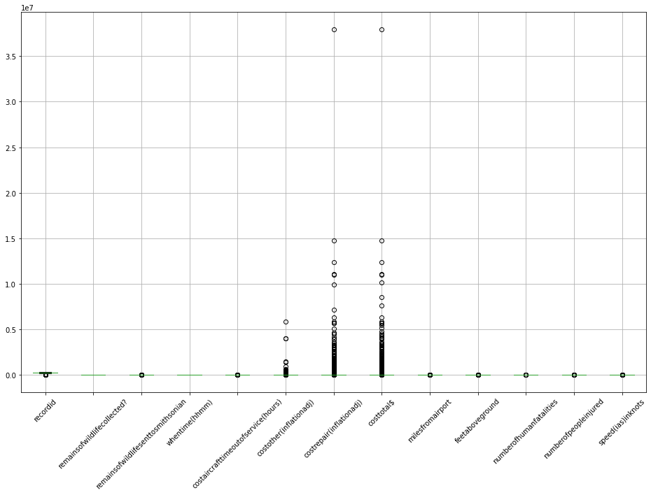

```python
plt.figure(figsize=(16,10))
df.boxplot()
plt.xticks(rotation=45);   # rotates x values to be more visible
```

```python
# sort values by costtotal$ column

df.sort_values('costtotal$', ascending=False).head(2)
```

| flightdate | aircrafttype | airportname | altitudebin | aircraftmake/model | wildlifenumberstruck | effectimpacttoflight | effectother | locationnearbyifenroute | aircraftflightnumber | recordid | effectindicateddamage | locationfreeformenroute | aircraftnumberofengines? | aircraftairline/operator | originstate | whenphaseofflight | conditionsprecipitation | remainsofwildlifecollected? | remainsofwildlifesenttosmithsonian | remarks | reporteddate | wildlifesize | conditionssky | wildlifespecies | whentime(hhmm) | whentimeofday | pilotwarnedofbirdsorwildlife? | costaircrafttimeoutofservice(hours) | costother(inflationadj) | … |
| --- | --- | --- | --- | --- | --- | --- | --- | --- | --- | --- | --- | --- | --- | --- | --- | --- | --- | --- | --- | --- | --- | --- | --- | --- | --- | --- | --- | --- | --- | --- |
| 2009-01-15 | Airplane | LAGUARDIA NY | > 1000 ft | A-320 | 2 to 10 | Other | CONTROLLED EMERGENCY LANDING ON THE HUDSON RIVER | NaN | 1549 | 258727 | Caused damage | NaN | 2 | US AIRWAYS | New York | Climb | None | True | True | ID BY SMITHSONIAN, FAA 3000. NTSB DCA09MA026. ... | NaT | Large | Some Cloud | Canada goose | 1530.0 | Day | NaN | NaN | 0 | … |
| 2009-02-03 | Airplane | DENVER INTL AIRPORT | > 1000 ft | B-757-200 | 1 | Precautionary Landing | AMBER ALERT, EMERGENCY EQUIPMENT CALLED OUT | NaN | 77 | 262533 | Caused damage | NaN | 2 | UNITED AIRLINES | Colorado | Climb | None | True | True | ID BY SMITHSONIAN, FAA 3023 AND 3075. WHOLE F... | NaT | Large | No Cloud | Bald eagle | 1320.0 | Day | NaN | NaN | 0 | … |

https://www.theguardian.com/world/2009/jan/15/us-airways-plane-crash-new-york-hudson-river

# General Questions

#### What are different impacts to flight?

```python
# value_counts() is good enough to answer simple BI questions

df['effectimpacttoflight'].value_counts()
```

```
None                     49699
Precautionary Landing     3639
Other                     1359
Aborted Take-off          1300
Engine Shut Down           228
Name: effectimpacttoflight, dtype: int64
```

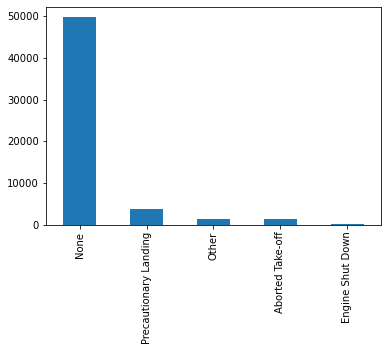

```python
df['effectimpacttoflight'].value_counts().plot(kind='bar')
```

```python
imp = df['effectimpacttoflight'].value_counts()
imp
```

```
None                     49699
Precautionary Landing     3639
Other                     1359
Aborted Take-off          1300
Engine Shut Down           228
Name: effectimpacttoflight, dtype: int64
```

Remove None from chart

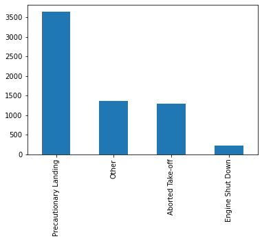

```python
imp[1:].plot(kind='bar')
```

```python
# groupby & size is same as value_counts()
df.groupby('effectimpacttoflight').size()
```

```
effectimpacttoflight
Aborted Take-off          1300
Engine Shut Down           228
None                     49699
Other                     1359
Precautionary Landing     3639
dtype: int64
```

```python
df.groupby('effectimpacttoflight').size().sort_values()
```

```
effectimpacttoflight
Engine Shut Down           228
Aborted Take-off          1300
Other                     1359
Precautionary Landing     3639
None                     49699
dtype: int64
```

```python
df.groupby('effectimpacttoflight').size().sort_values()[:-1]
```

```
effectimpacttoflight
Engine Shut Down          228
Aborted Take-off         1300
Other                    1359
Precautionary Landing    3639
dtype: int64
```

```python
# HOW TO REMOVE "other"
result = df.groupby('effectimpacttoflight').size().reset_index()
result.loc[result['effectimpacttoflight'] != 'Other']
```

|  | effectimpacttoflight | 0 |
| --- | --- | --- |
| 0 | Aborted Take-off | 1300 |
| 1 | Engine Shut Down | 228 |
| 2 | None | 49699 |
| 4 | Precautionary Landing | 3639 |

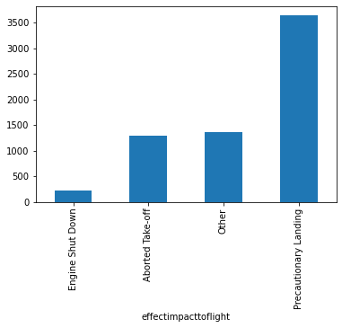

```python
# plot the above pivot
df.groupby('effectimpacttoflight').size().sort_values()[:-1].plot(kind='bar')
```

Customizing plots with .plot() parameters You can customize plots a number of ways. Here’s a quick guide to common parameters: kind=: ‘line’, ‘bar’, ‘barh’, ‘hist’, ‘box’, ‘area’, ‘scatter‘ figsize=: (width, height) in inches colormap=: a long list of color palettes, including: ‘autumn’, ‘winter’, ‘summer‘ title=: a string stacked=: stack the values vertically (instead of allowing them to overlap) source: https://community.modeanalytics.com/python/tutorial/pandas-groupby-and-python-lambda-functions/

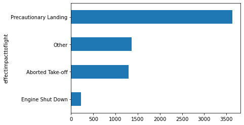

```python
# barh plot

df.groupby('effectimpacttoflight').size().sort_values()[:-1].plot(kind='barh')
```

#### What is the total cost in dollars?

```python
df['costtotal$'].sum()
```

```
468730397
```

#### what is the total "numberofpeopleinjured"?

```python
df['numberofpeopleinjured'].sum()
```

```
140.0
```

#### How many incidents cause more than $1,000,000?

```python
len(df.loc[df['costtotal$'] > 1000000])
```

```
84
```

#### How many incidents cause more than $2,000,000?

```python
len(df.loc[df['costtotal$'] > 2000000])
```

```
45
```

#### Which departure airport has the most cases of bird strikes?

```python
df.groupby('airportname').size().sort_values(ascending=False).head()
```

```
airportname
UNKNOWN                        10857
DENVER INTL AIRPORT             3397
DALLAS/FORT WORTH INTL ARPT     2562
CHICAGO O'HARE INTL ARPT        1907
JOHN F KENNEDY INTL             1859
dtype: int64
```

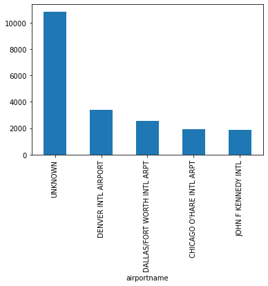

```python
# plot top 5 airports

df.groupby('airportname').size().sort_values(ascending=False).head().plot(kind='bar')
```

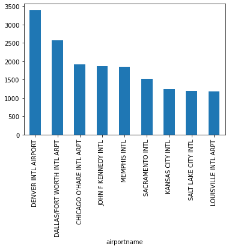

```python
# plot top 10 airports
# [1:] removes UNKNOWN

df.groupby('airportname').size().sort_values(ascending=False).head(10)[1:].plot(kind='bar')
```

#### Which departure airport has the highest total monetary costs (costtotal$) as a result of bird strikes?

```python
df.groupby('airportname')['costtotal$'].sum().sort_values(ascending=False).head()
```

```
airportname
LAGUARDIA NY               38696402
UNKNOWN                    28340848
DENVER INTL AIRPORT        26096643
SUBIC BAY INTL             23956861
SAN FRANCISCO INTL ARPT    21134735
Name: costtotal$, dtype: int64
```

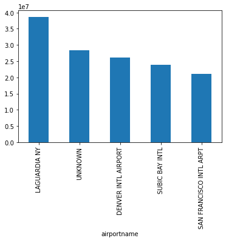

```python
# plot
df.groupby('airportname')['costtotal$'].sum().sort_values(ascending=False).head().plot(kind='bar')
```

#### Which departure airport / originstate has the highest numberofpeopleinjured as a result of bird strikes?

```python
df.groupby('airportname')['numberofpeopleinjured'].sum().sort_values(ascending=False).head()
```

```
airportname
UNKNOWN                                65.0
ST LOUIS DOWNTOWN                       7.0
BRUSSELS NATIONAL                       4.0
DON MUEANG INTL ARPT  (OLD BANGKOK)     4.0
MATINICUS ISLAND ARPT                   2.0
Name: numberofpeopleinjured, dtype: float64
```

```python
df.groupby('originstate')['numberofpeopleinjured'].sum().sort_values(ascending=False).head()
```

```
originstate
Florida       24.0
Arizona        9.0
California     9.0
Texas          9.0
Illinois       8.0
Name: numberofpeopleinjured, dtype: float64
```

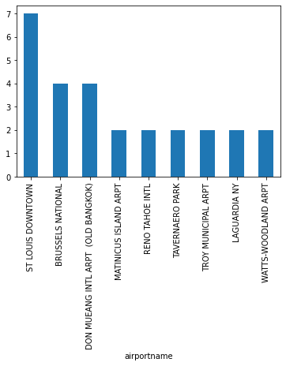

```python
# plot top 10 airports

df.groupby('airportname')['numberofpeopleinjured'].sum().sort_values(ascending=False).head(10)[1:].plot(kind='bar')
```

#### Which departure state has the highest total monetary costs as a result of bird strikes?

```python
df.groupby('originstate')['costtotal$'].sum().sort_values(ascending=False).head()
```

```
originstate
California    49725323
New York      45887923
Colorado      28786962
Florida       25310845
Oregon        17945515
Name: costtotal$, dtype: int64
```

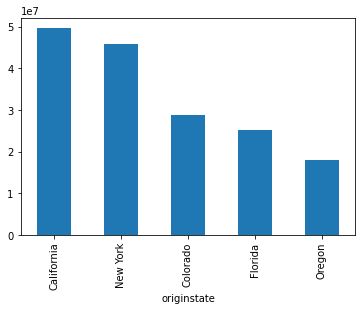

```python
# plot

df.groupby('originstate')['costtotal$'].sum(). \
sort_values(ascending=False).head().plot(kind='bar')
```

#### Which departure state (originstate) has the highest number of bird strike cases?

```python
df.groupby('originstate').size().sort_values(ascending=False).head()
```

```
originstate
Texas         7824
California    7803
Florida       5322
New York      4986
Colorado      4214
dtype: int64
```

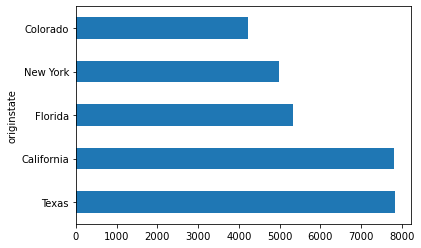

```python
# plot top 5 airports mentioned above
df.groupby('originstate').size().sort_values(ascending=False).head().plot(kind='barh')
```

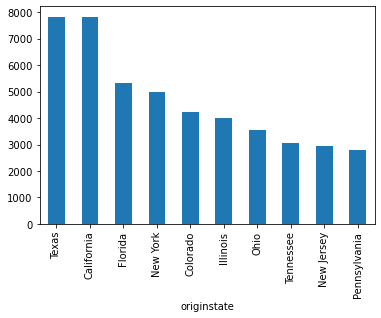

```python
# plot top 10 originstate with the highest number of bird strike cases
df.groupby('originstate').size().sort_values(ascending=False).head(10).plot(kind='bar')
```

#### What is the average "speed" for the airplanes with bird strikes from the states of origin?

```python
df.groupby('originstate')['speed(ias)inknots'].mean().sort_values(ascending=False).head()
```

```
originstate
Louisiana    358.438509
Manitoba     182.500000
Nevada       168.216450
Quebec       164.705882
Ontario      161.600000
Name: speed(ias)inknots, dtype: float64
```

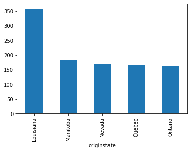

```python
# plot

df.groupby('originstate')['speed(ias)inknots'].mean(). \
sort_values(ascending=False).head().plot(kind='bar')
```

#### Which "aircraftmake/model" has the highest average speed?

```python
df.groupby('aircraftmake/model')['speed(ias)inknots'].mean().sort_values(ascending=False).head()
```

```
aircraftmake/model
B-52H         1150.802395
T-38N          300.000000
F-15E          250.000000
EMB 500        250.000000
BA-146-100     250.000000
Name: speed(ias)inknots, dtype: float64
```

#### Which "aircraftmake/model" has the highest cases of bird strikes?

```python
df.groupby('aircraftmake/model').size().sort_values(ascending=False).head()
```

```
aircraftmake/model
UNKNOWN         24637
B-737-300        5524
A-320            4654
CL-RJ100/200     4262
B-737-700        4046
dtype: int64
```

[figure not shown]